# Handling Missing Values under MAR

### Objective

To understand the concept of **Missing at Random (MAR)** and fill missing values using information available in other observed variables.

### Dataset

**Titanic Dataset**

Important columns:

| Column | Meaning |
| --- | --- |
| `Survived` | Survival status |
| `Pclass` | Passenger class |
| `gender` | Gender |
| `Age` | Passenger age |
| `SibSp` | Siblings/spouses aboard |
| `Parch` | Parents/children aboard |
| `Fare` | Ticket fare |
| `Embarked` | Port of embarkation |

The original dataset contains **891 passengers**, with `Age` observed for 714 passengers, meaning **177 Age values are missing**.

## Step 1 — Load the Real Dataset

```python
import pandas as pd

df = pd.read_csv("titanic.csv")

print(df.head())
print(df.shape)
```

```
   survived  pclass  gender   age  sibsp  parch     fare embarked  class  \
0         0       3    male  22.0      1      0   7.2500        S  Third
1         1       1  female  38.0      1      0  71.2833        C  First
2         1       3  female  26.0      0      0   7.9250        S  Third
3         1       1  female  35.0      1      0  53.1000        S  First
4         0       3    male  35.0      0      0   8.0500        S  Third

     who  adult_male deck  embark_town alive  alone
0    man        True  NaN  Southampton    no  False
1  woman       False    C    Cherbourg   yes  False
2  woman       False  NaN  Southampton   yes   True
3  woman       False    C  Southampton   yes  False
4    man        True  NaN  Southampton    no   True
(891, 15)
```

## Step 2 — Identify Missing Values

First, check how many missing values are present in each column.

```
df.isnull().sum()
```

```python
df.isnull().sum()
```

```
survived         0
pclass           0
gender           0
age            177
sibsp            0
parch            0
fare             0
embarked         2
class            0
who              0
adult_male       0
deck           688
embark_town      2
alive            0
alone            0
dtype: int64
```

## Think About MAR

Before filling the missing `Age` values, we should ask:

> **Is the missingness in `Age` related to other observed variables?**

For example, passenger age may be related to variables such as:

- `Pclass` — passenger class
- `gender` — gender
- `Fare` — ticket fare
- `SibSp` — siblings/spouses aboard
- `Parch` — parents/children aboard

If the probability of `Age` being missing depends on these **observed variables**, the missingness can be considered **Missing at Random (MAR)**.

### Example

Suppose we discover that `Age` is missing more frequently for passengers in **Pclass 3** than in Pclass 1 or 2.

Then:

```
Age missingness
       ↓
related to Pclass
       ↓
Pclass is observed
       ↓
Possible MAR pattern
```

```python
df["age"].mean()
```

```
np.float64(29.69911764705882)
```

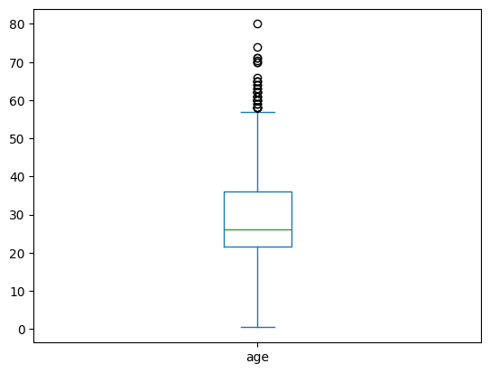

```python
df["age"].plot(kind="box")
```

```python
df.loc[df["age"] > 70,"age"]
```

```
96     71.0
116    70.5
493    71.0
630    80.0
851    74.0
Name: age, dtype: float64
```

```python
df.groupby("gender")["age"].mean()
```

```
gender
female    27.915709
male      30.726645
Name: age, dtype: float64
```

```python
df.groupby("pclass")["age"].mean()
```

```
pclass
1    38.233441
2    29.877630
3    25.140620
Name: age, dtype: float64
```

```python
df.groupby(["gender", "pclass"])["age"].mean()
```

```
gender  pclass
female  1         34.611765
        2         28.722973
        3         21.750000
male    1         41.281386
        2         30.740707
        3         26.507589
Name: age, dtype: float64
```

# Fill Age Using Gender + Pclass

This is the actual **MAR-style imputation**.

Instead of using one overall median age, we use **two observed variables—`Gender` and `Pclass`—to estimate the missing `Age` values**.

The idea is:

```
Missing Age
     ↓
Look at Gender + Pclass
     ↓
Find the typical Age for that group
     ↓
Use that value to fill the missing Age
```

```python
df["age"].isnull().sum()
```

```
np.int64(177)
```